# DA 460 Final Exam

Marjorie Blanco

August 12, 2018

# Final Exam Part 1 – R

## Problem 1

Read the data set run10.csv (or run10.txt), and answer the following questions.

### Question 1

Download run10.csv (or run10.txt) and read corresponding data into R.

### Question 2

Calculate the population mean and standard deviation for `divTot`. Apply `rep` function and `for` loop to collect 50 simple random samples of size 100 from `divTot`, and then use these stored statistics to calculate 50 confidence intervals of 95% confidence level for population mean.

```r
# the ground living area
population <- run$divTot

#Calculate the population mean and standard deviation for `divTot`
summary(run$divTot)
```

```
##    Min. 1st Qu.  Median    Mean 3rd Qu.    Max.
##       1     931    1367    1440    2228    2782
```

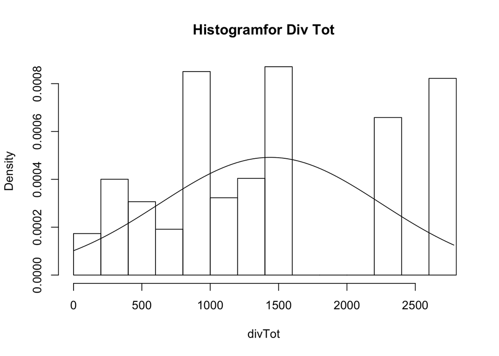

```r
xlimits <- range(run$divTot)
hist(run$divTot, main = "Histogramfor Div Tot", xlab = "divTot", xlim = xlimits, prob=TRUE)
curve(dnorm(x, mean=mean(run$divTot), sd=sd(run$divTot)), add=TRUE)
```

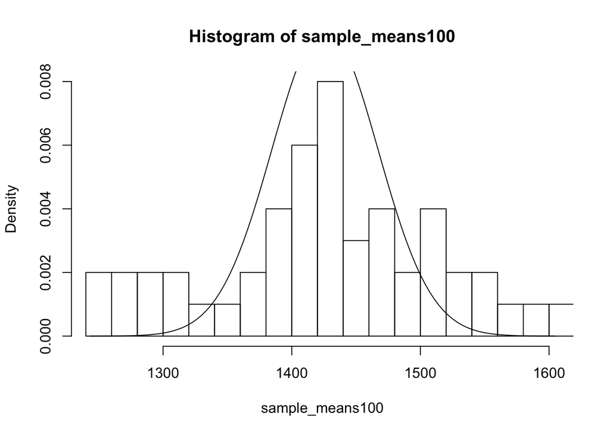

```r
# create vector to save mean for 50 samples of size 100
sample_means100 <- rep(NA, 50)
# create vector to save standard deviation for 50 samples of size 100
sample_sd <- rep(NA, 50)

# sample size
n <- 100

for(i in 1:length(sample_means100)){
   # simple random sample of size 100
   samp <- sample(population, 100)        # save sample
   sample_means100[i] <- mean(samp) # save sample mean in ith element of sample_means100
   sample_sd[i] <- sd(samp)         # save sample sd in ith element of sample_sd
}

# histogram of mean for 50 samples of size 100
xlimits <- range(sample_means100)
hist(sample_means100, breaks = 20, xlim = xlimits, prob=TRUE)
curve(dnorm(x, mean=mean(sample_means100), sd=sd(sample_sd)), add=TRUE)
```

```r
# construct the confidence intervals.
lower_vector <- sample_means100 - qnorm(.975) * sample_sd / sqrt(n)
upper_vector <- sample_means100 + qnorm(.975) * sample_sd / sqrt(n)

# display for confidence interval for first 5 random samples
sample <- data.frame(lower_vector)
sample$mean <- sample_means100
sample$upper <- upper_vector
head(sample, n=5)
```

```
##   lower_vector mean upper
## 1         1219 1373  1527
## 2         1252 1410  1567
## 3         1330 1482  1634
## 4         1246 1397  1547
## 5         1258 1423  1589
```

The population mean is 1440.3268 and standard deviation for `divTot` is 811.1689.

```r
inference(y = divTot, data = run, statistic = "mean", type = "ci", null = 0,
          alternative = "twosided", method = "theoretical")
```

```
## Single numerical variable
## n = 16923, y-bar = 1440.3268, s = 811.1689
## 95% CI: (1428.1046 , 1452.5491)
```

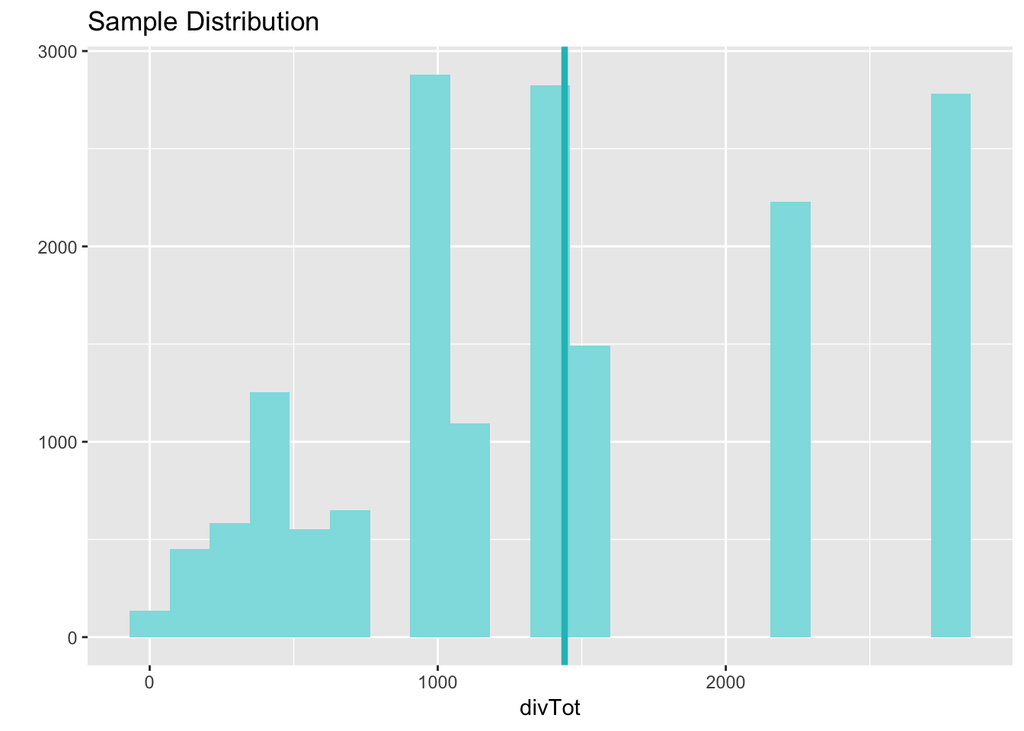

The 95 % confidence interval for the mean divTot is between 1428.1046 and 1452.5491

### Question 3

Apply function plot_ci to display all the 50 confidence intervals in question (2). What proportion of your confidence intervals include the true population mean? Is this proportion consistent with the confidence level? Why or why not?

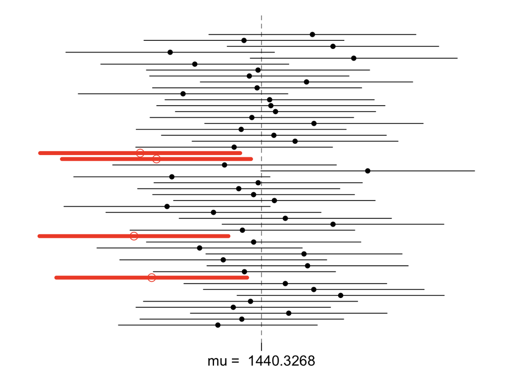

```r
plot_ci(lower_vector, upper_vector, mean(population))
```

```r
# proportion calculation
p <- 1-(sum(lower_vector > mean(population) | upper_vector < mean(population))/50)
p
```

```
## [1] 0.92
```

The 92% of the confidence intervals include the true population mean. This proportion is not exactly equal to the confidence level of 95%.

4 out ofthe 50 intervals did not include the true mean, mu=1440.327, which is roughly 92%. About 95% will likely include the true value of the population.

### Question 4

Make a side-by-side boxplot of gender and divTot. What does the plot highlight about the relationship between these two variables?

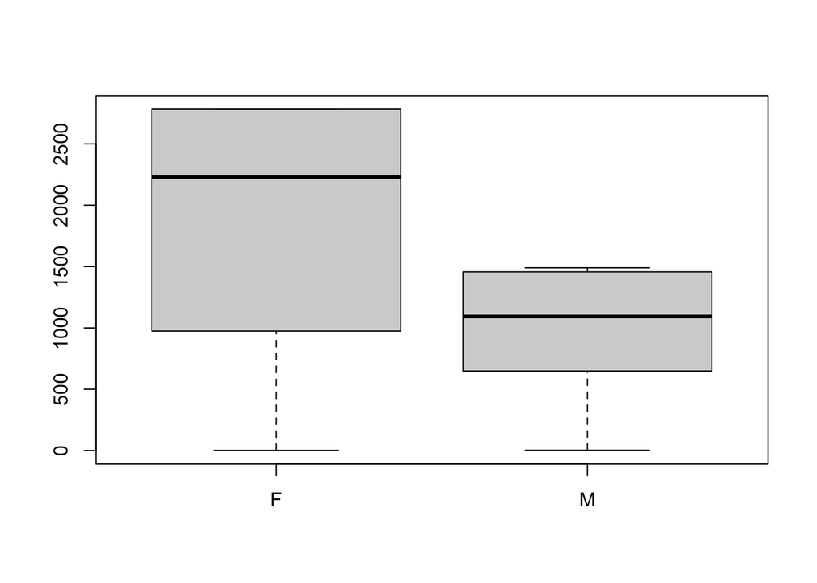

```r
boxplot(run$divTot ~ run$gender, col="lightgray")
```

```r
by(run$divTot, run$gender, mean)
```

```
## run$gender: F
## [1] 1747
## --------------------------------------------------------
## run$gender: M
## [1] 1025
```

The mean divTot for female is significantly higher than the mean for divTot for male.

### Question 5

Calculate and a 95% confidence intervals for the difference between the mean of male divTot and the mean of female divTot, and interpret.

```r
run$gender <- as.factor(run$gender)

divTotMale <- run[run$gender == "M", "divTot"]
divTotFemale <- run[run$gender == "F", "divTot"]
summary(divTotMale)
```

```
##      divTot
##  Min.   :   2
##  1st Qu.: 648
##  Median :1093
##  Mean   :1025
##  3rd Qu.:1457
##  Max.   :1490
```

```r
summary(divTotFemale)
```

```
##      divTot
##  Min.   :   1
##  1st Qu.: 974
##  Median :2228
##  Mean   :1748
##  3rd Qu.:2782
##  Max.   :2782
```

```r
summary(run$divTot)
```

```
##    Min. 1st Qu.  Median    Mean 3rd Qu.    Max.
##       1     931    1367    1440    2228    2782
```

```r
inference(y = divTot, data = divTotMale, statistic = "mean", type = "ci", null = 0,
          alternative = "twosided", method = "theoretical")
```

```
## Single numerical variable
## n = 7191, y-bar = 1024.6215, s = 449.3532
## 95% CI: (1014.2339 , 1035.0091)
```

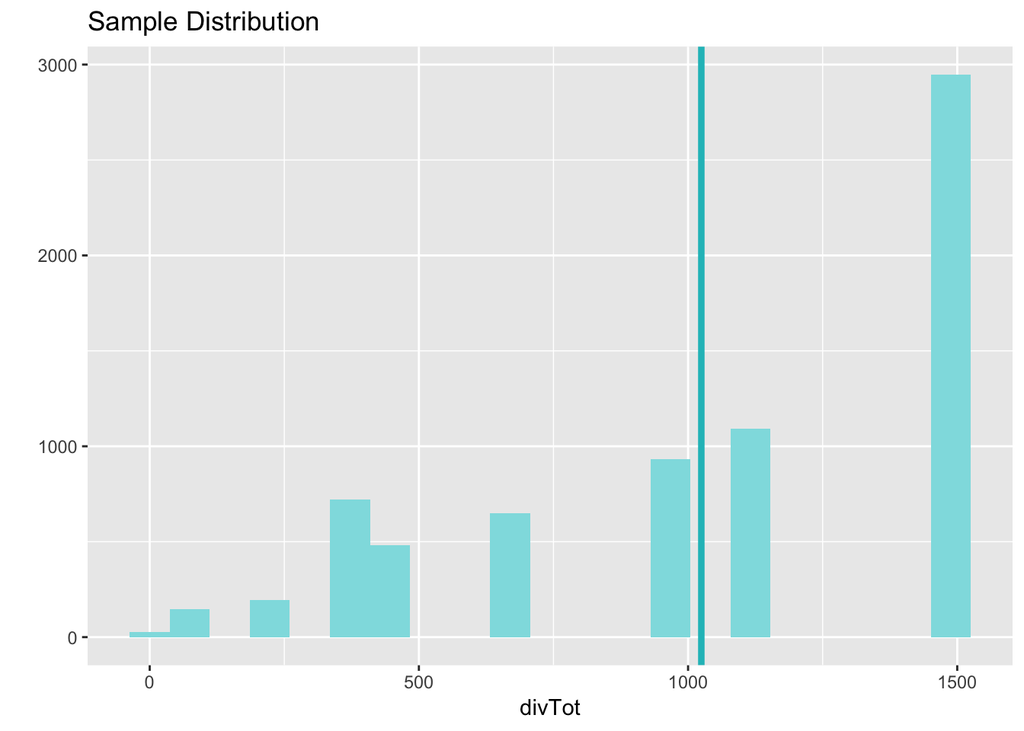

The 95 % confidence interval the mean of divTot for male is between 1014.2339 and 1035.0091

```r
inference(y = divTot, data = divTotFemale, statistic = "mean", type = "ci", null = 0,
          alternative = "twosided", method = "theoretical")
```

```
## Single numerical variable
## n = 9732, y-bar = 1747.4926, s = 879.1942
## 95% CI: (1730.0229 , 1764.9623)
```

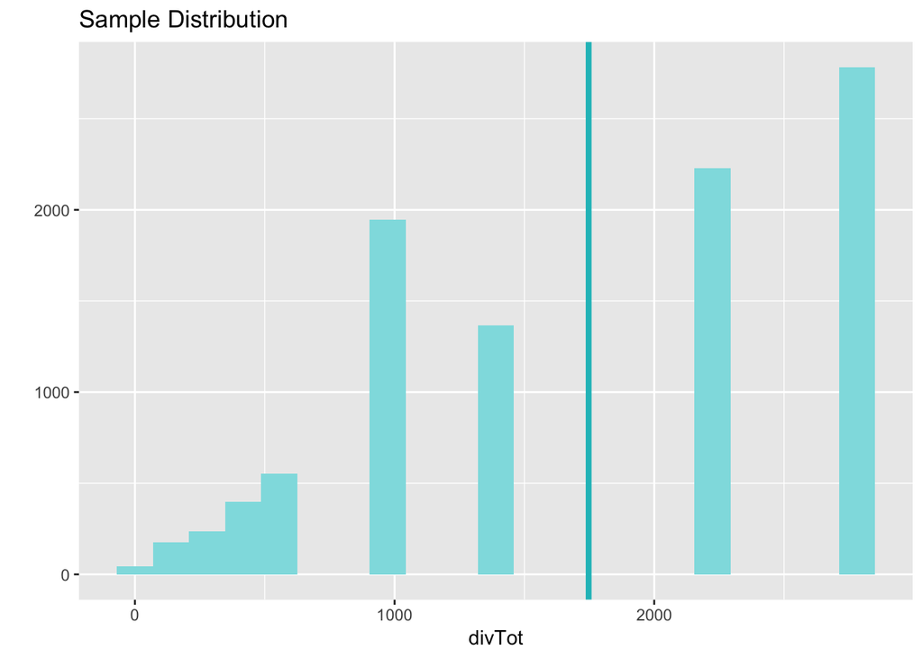

The 95 % confidence interval the mean of divTot for female is between 1730.0229 and 1764.9623

```r
inference(y = divTot, x = gender, data = run, statistic = "mean", type = "ci", null = 0,
          alternative = "twosided", method = "theoretical",
          order = c("F","M"))
```

```
## Response variable: numerical, Explanatory variable: categorical (2 levels)
## n_F = 9732, y_bar_F = 1747.4926, s_F = 879.1942
## n_M = 7191, y_bar_M = 1024.6215, s_M = 449.3532
## 95% CI (F - M): (702.5458 , 743.1965)
```

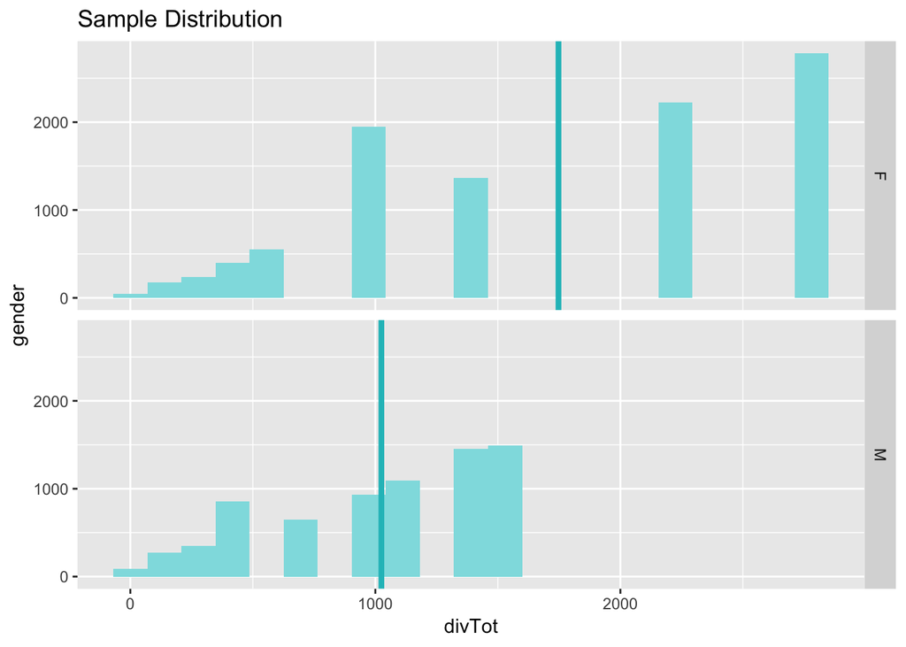

### Question 6

Conduct a hypothesis test at 95% significant level evaluating whether the mean of male divTot is different from the mean of female divTot? Make sure you indicate the hypotheses, the test rest, and the conclusion(s) clearly.

H0: mu_divTot_female - mu_divTot_male = 0

The mean of female divTot is the same as the mean of male divTot

HA: mu_divTot_female - mu_divTot_male != 0

The mean of female divTot is different from the mean of male divTot

```r
# inference is use for conducting hypothesis tests and constructing confidence intervals
inference(y = divTot, x = gender, data = run, statistic = "mean", type = "ht", null = 0,
          alternative = "twosided", method = "theoretical",
          order = c("F","M"))
```

```
## Response variable: numerical
## Explanatory variable: categorical (2 levels)
## n_F = 9732, y_bar_F = 1747.4926, s_F = 879.1942
## n_M = 7191, y_bar_M = 1024.6215, s_M = 449.3532
## H0: mu_F =  mu_M
## HA: mu_F != mu_M
## t = 69.7179, df = 7190
## p_value = < 0.0001
```

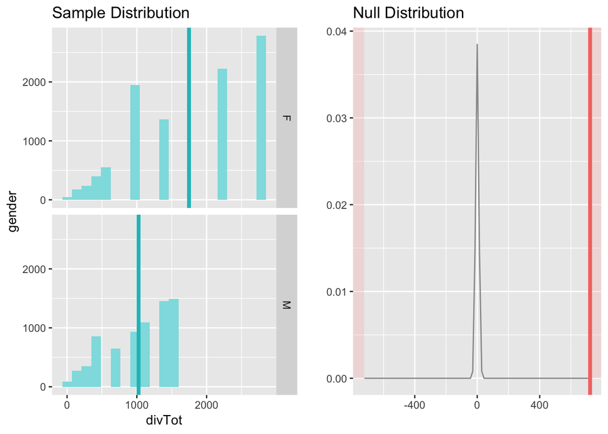

The p-value is less than 0.05 therefore we reject the null hypothesis in favor of the alternative hypothesis. The mean of male divTot is different from the mean of female divTot.

## Problem 2

Read the data set smoking.csv (or smoking.txt), and answer the following questions.

### Question 1

Download smoking.csv (or smoking.txt) and read corresponding data into R.

```r
# read data set
smoking <- read_csv("smoking.csv")
head(smoking)
```

```
## # A tibble: 6 x 12
##   gender   age maritalStatus highestQualification nationality ethnicity
##   <chr>  <int> <chr>         <chr>                <chr>       <chr>
## 1 Male      38 Divorced      No Qualification     British     White
## 2 Female    42 Single        No Qualification     British     White
## 3 Male      40 Married       Degree               English     White
## 4 Female    40 Married       Degree               English     White
## 5 Female    39 Married       GCSE/O Level         British     White
## 6 Female    37 Married       GCSE/O Level         British     White
## # ... with 6 more variables: grossIncome <chr>, region <chr>, smoke <chr>,
## #   amtWeekends <int>, amtWeekdays <int>, type <chr>
```

### Question 2

Create a new data frame that contains only the rows in smoking.csv associated with male smokers (Male for `gender` and Yes for `smoke`). Then, calculate the proportion of Divorced in `maritalStatus`.

```r
male_smoke <- smoking[smoking$gender == "Male" & smoking$smoke == "Yes", ]
head(male_smoke)
```

```
## # A tibble: 6 x 12
##   gender   age maritalStatus highestQualification nationality ethnicity
##   <chr>  <int> <chr>         <chr>                <chr>       <chr>
## 1 Male      53 Married       Degree               British     White
## 2 Male      40 Single        GCSE/CSE             English     White
## 3 Male      59 Married       Other/Sub Degree     English     White
## 4 Male      28 Married       Other/Sub Degree     British     White
## 5 Male      67 Widowed       No Qualification     British     White
## 6 Male      40 Married       Other/Sub Degree     English     White
## # ... with 6 more variables: grossIncome <chr>, region <chr>, smoke <chr>,
## #   amtWeekends <int>, amtWeekdays <int>, type <chr>
```

```r
p <- round(nrow(male_smoke[male_smoke$maritalStatus == "Divorced",])/nrow(male_smoke), 4)
p
```

```
## [1] 0.0856
```

```r
male_smoke$maritalStatus2 <- male_smoke$maritalStatus
male_smoke[male_smoke$maritalStatus2 != "Divorced", "maritalStatus2"] <- "Not Divorced"
```

```r
inference(y=maritalStatus2, data=male_smoke, type = "ci", success = "Divorced", statistic = "proportion", method = "theoretical")
```

```
## Single categorical variable, success: Divorced
## n = 187, p-hat = 0.0856
## 95% CI: (0.0455 , 0.1257)
```

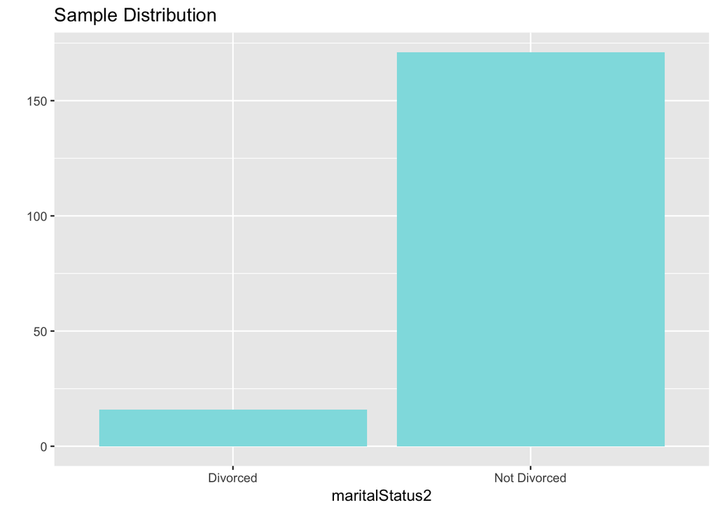

The proportion of Divorced in `maritalStatus` is 8.56%

### Question 3

Check if the conditions for inference are reasonable. If so, apply `inference` function to calculate the standard error and construct a 95% confidence interval for the proportion of Divorced in `maritalStatus`.

#### Success-failure

np = 187 * 0.0856 = 16.0072 >= 10

n (1-p) = 187 * 0.9144 = 170.9928 >= 10

The success-failure condition was met.

### Question 4

Based on the R output in question (3), what is the standard error and the margin of error for the estimate of the proportion of Divorced in `maritalStatus`?

```r
inference(y = maritalStatus2, data = male_smoke, statistic = "proportion", type = "ci", method = "theoretical",
                   success = "Divorced")
```

```
## Single categorical variable, success: Divorced
## n = 187, p-hat = 0.0856
## 95% CI: (0.0455 , 0.1257)
```

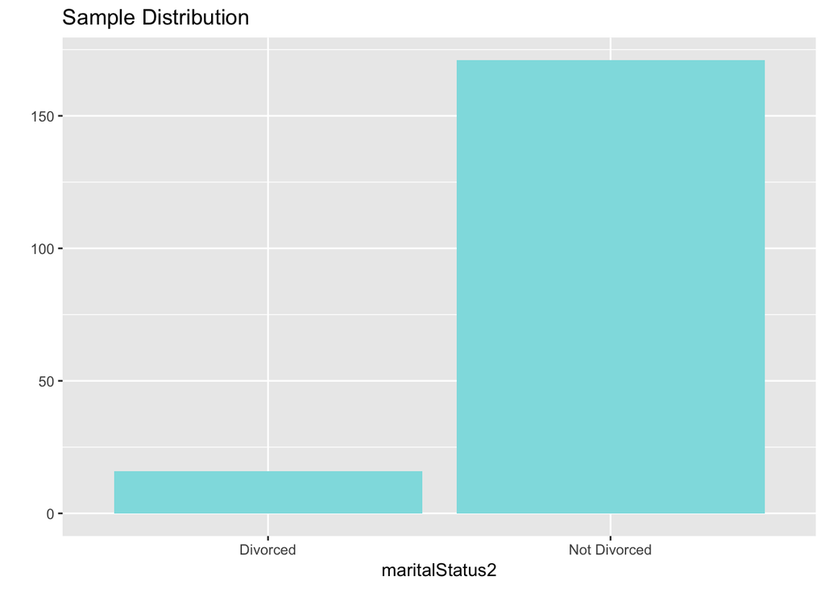

```r
# Margin of error: z * (standard of error)
# 95%: z = 1.96
me <- qnorm(.975) * 0.0205
me
```

```
## [1] 0.04018
```

```r
paste("Margin of Error: +/-", me)
```

```
## [1] "Margin of Error: +/- 0.0401792616830711"
```

The standard error is 0.0205.

The margin of error is 0.0402.

We are 95% confident that the confidence interval between 0.0455 and 0.1257 covers the true population proportion.

### Question 5

Use simulation to show how the proportion affect the margin of error. Describe the relationship between the proportion and the margin of error.

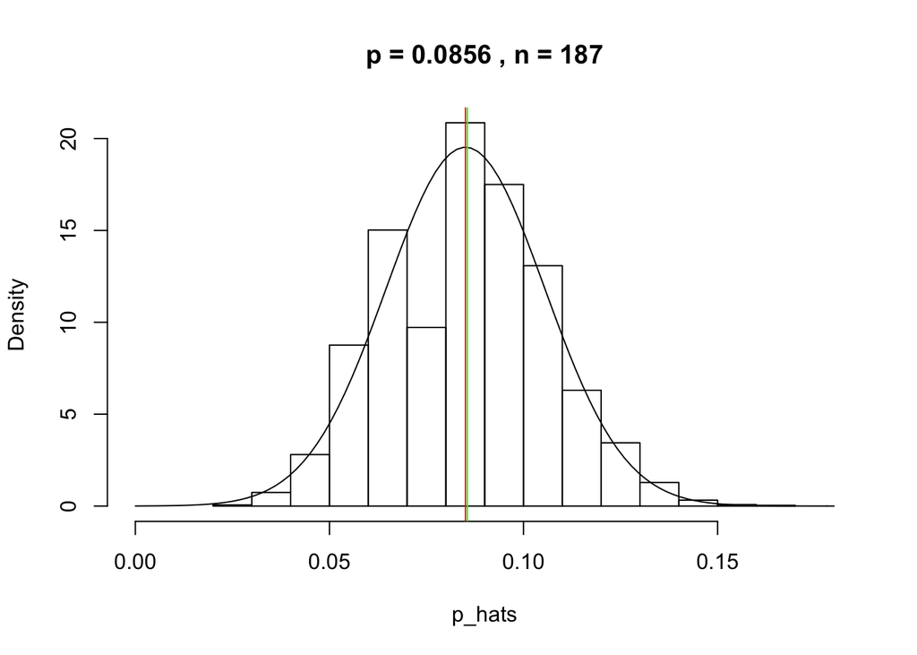

```r
title <- paste( "p =" , toString(p), ", n =" , toString(nrow(male_smoke)), sep = " ")
n <- nrow(male_smoke)
p_hats <- rep(0, 5000)

for(i in 1:length(p_hats)){
  samp <- sample(c("Divorced", "Not Divorced"), n, replace = TRUE, prob = c(p, 1-p))
  p_hats[i] <- sum(samp == "Divorced")/n
}

hist(p_hats, main = title, xlim = c(0, 0.18), prob=TRUE)
curve(dnorm(x, mean=mean(p_hats), sd=sd(p_hats)), add=TRUE)

# sample mean
abline(v=mean(p_hats), col="red")
# sample mean
abline(v=median(p_hats), col="green")
```

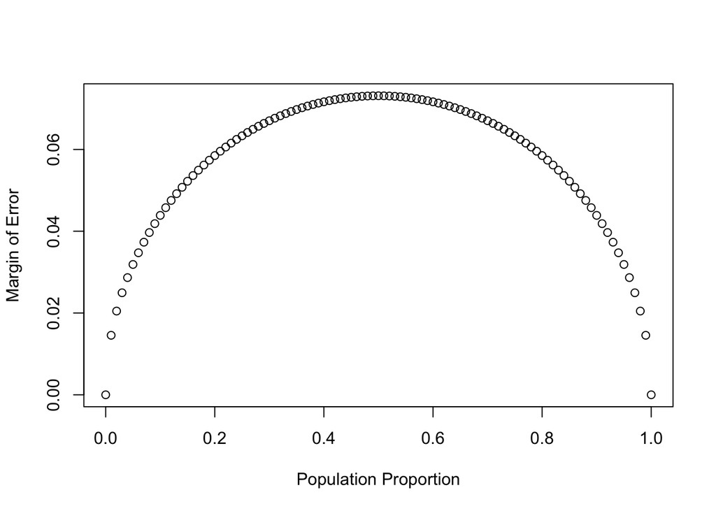

```r
n <- nrow(male_smoke)
p <- seq(0, 1, 0.01)
me <- 2 * sqrt(p * (1 - p)/n)
plot(me ~ p, ylab = "Margin of Error", xlab = "Population Proportion")
```

The proportion of 0.5 is the proportion that will have the largest margin of error (0.0731). As p comes near to 0.5 the bigger margin of error will be and as p comes near 0 or 1 the lower margin of error will be.

### Question 6

Apply `for` loop to simulate the process of drawing 300 samples of size 1000 from a population with a true Divorced proportion of 0.3. For each of the 3000 samples, compute 𝑝̂ and then plot a histogram to visualize the distribution. Describe the sampling distribution of the sample proportions. Be sure to note the center, spread, and shape clearly.

Case: Sample size = 300, n=1000 and p=0.3

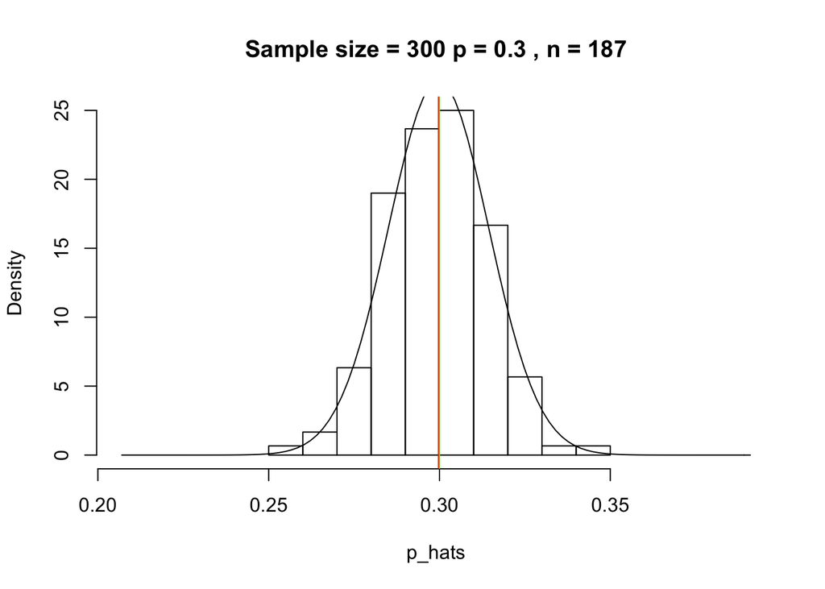

```r
p <- 0.3
n <- 1000
size <- 300
p_hats <- rep(0, size)

title <- paste( "Sample size =", size, "p =" , toString(p), ", n =" , toString(nrow(male_smoke)), sep = " ")

for(i in 1:length(p_hats)){
  samp <- sample(c("Divorced", "NonDivorced"), n, replace = TRUE, prob = c(p, 1-p))
  p_hats[i] <- sum(samp == "Divorced")/n
}

hist(p_hats, main = title, xlim = c(min(p_hats)-0.05, max(p_hats)+0.05), prob=TRUE)
curve(dnorm(x, mean=mean(p_hats), sd=sd(p_hats)), add=TRUE)

# sample mean
abline(v=mean(p_hats), col="red")
# sample mean
abline(v=median(p_hats), col="green")
```

```r
summary(p_hats)
```

```
##    Min. 1st Qu.  Median    Mean 3rd Qu.    Max.
##   0.257   0.289   0.300   0.300   0.310   0.341
```

The mean is 0.3, median is 0.3, and the range is between 0.257 to 0.341.

The data follow follows a normal distribution.

- Mean: 0.2997
- Median: 0.3
- SD: 0.0147

Case: Sample size = 3000, n=1000 and p=0.3

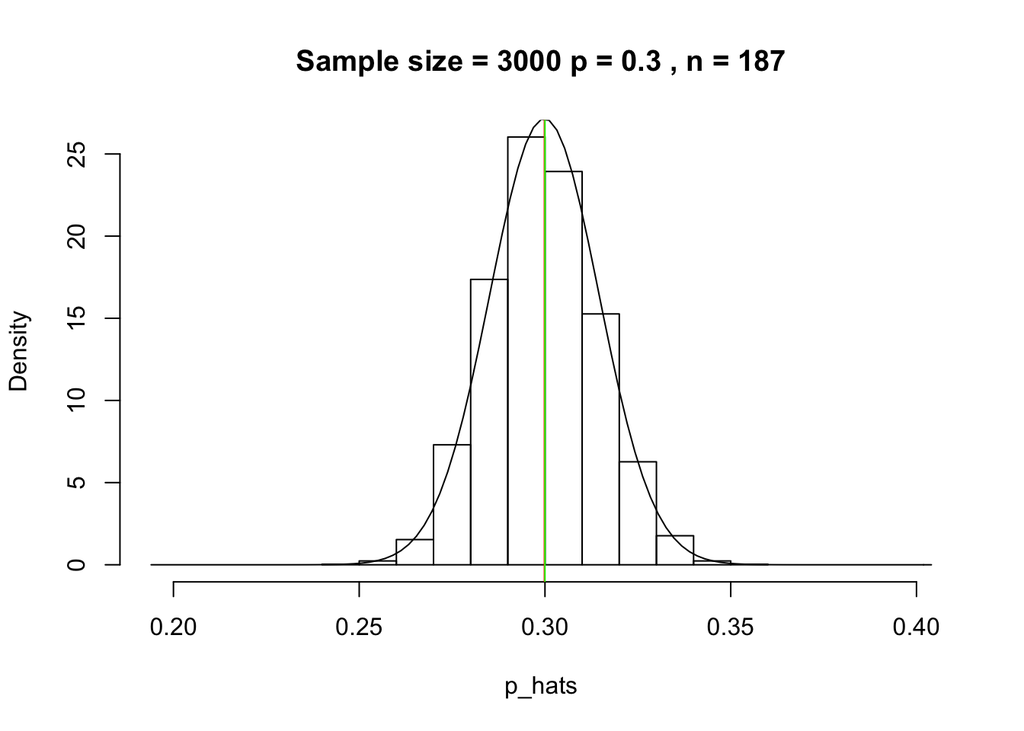

```r
p <- 0.3
n <- 1000
size <- 3000
p_hats <- rep(0, size)

title <- paste( "Sample size =", size, "p =" , toString(p), ", n =" , toString(nrow(male_smoke)), sep = " ")

for(i in 1:length(p_hats)){
  samp <- sample(c("Divorced", "NonDivorced"), n, replace = TRUE, prob = c(p, 1-p))
  p_hats[i] <- sum(samp == "Divorced")/n
}

hist(p_hats, main = title, xlim = c(min(p_hats)-0.05, max(p_hats)+0.05), prob=TRUE)
curve(dnorm(x, mean=mean(p_hats), sd=sd(p_hats)), add=TRUE)

# sample mean
abline(v=mean(p_hats), col="red")
# sample mean
abline(v=median(p_hats), col="green")
```

```r
summary(p_hats)
```

```
##    Min. 1st Qu.  Median    Mean 3rd Qu.    Max.
##   0.244   0.290   0.300   0.300   0.310   0.354
```

The mean is 0.3, median is 0.3, and the range is between 0.244 to 0.354.

The data follow follows a normal distribution.

- Mean: 0.2998
- Median: 0.3
- SD: 0.0147

## Problem 3

### Question 1

Download diamonds.csv (or diamonds.txt) and read corresponding data into R.

```r
# read data set
diamonds <- read_csv("diamonds.csv")
head(diamonds)
```

```
## # A tibble: 6 x 10
##   carat cut       color clarity depth table price     x     y     z
##   <dbl> <chr>     <chr> <chr>   <dbl> <dbl> <int> <dbl> <dbl> <dbl>
## 1 0.23  Ideal     E     SI2      61.5    55   326  3.95  3.98  2.43
## 2 0.21  Premium   E     SI1      59.8    61   326  3.89  3.84  2.31
## 3 0.23  Good      E     VS1      56.9    65   327  4.05  4.07  2.31
## 4 0.290 Premium   I     VS2      62.4    58   334  4.2   4.23  2.63
## 5 0.31  Good      J     SI2      63.3    58   335  4.34  4.35  2.75
## 6 0.24  Very Good J     VVS2     62.8    57   336  3.94  3.96  2.48
```

### Question 2

What type of plot is the most appropriate one to display the relationship between `price` and `carat`? Plot this relationship using the variable `carat` as the predictor. Does the relationship look linear?

The scatter plot is the type of plot is the most appropriate one to display the relationship between `price` and `carat`. The relationship between `price` and `carat` appear to be linear.

```r
fit <- lm(price ~ carat, data = diamonds)
fit
```

```
##
## Call:
## lm(formula = price ~ carat, data = diamonds)
##
## Coefficients:
## (Intercept)        carat
##       -2256         7756
```

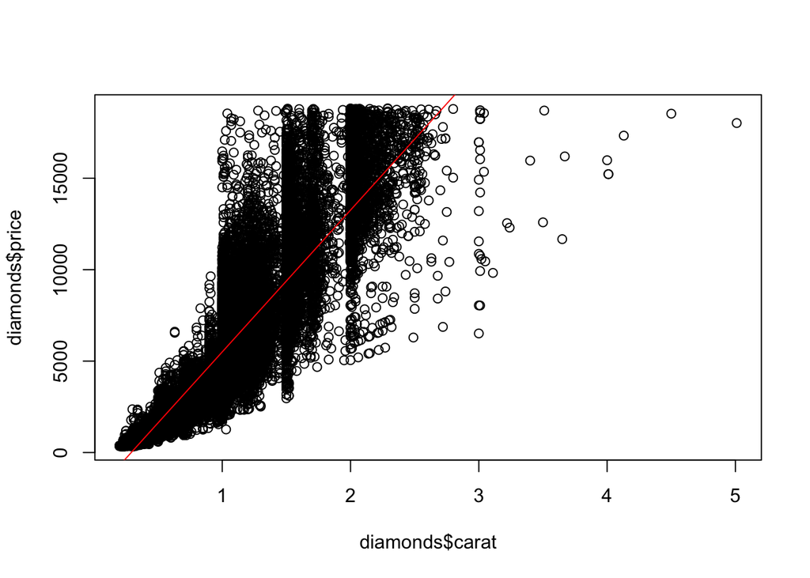

```r
fit <- lm(diamonds$price ~ diamonds$carat)
plot(diamonds$price ~ diamonds$carat)
abline(fit, col="red")
```

### Question 3

If the relationship looks linear in question (2), what is the correlation coefficient? Interpret this result.

```r
model_cor <- cor(diamonds$carat, diamonds$price)
model_cor
```

```
## [1] 0.9216
```

The correlation coefficient is 0.9216, which indicates a strong positive relationship.

### Question 4

Fit a simple linear model (use `carat` to predict `price`). Using the estimates from the R output, write down the regression equation. What are the y-intercept and the slope? Interpret the regression line. Is variable carat significant? Why or why not? What is the coefficient of determination? Interpret the results.

The y-intercept is -2256. The slope for `carat` is 7756. The variable `carat` is significant because the p-value is less than 0.05. The coefficient of determination is 0.849.

price = 7756 * carat - 2256

```r
fit
```

```
##
## Call:
## lm(formula = diamonds$price ~ diamonds$carat)
##
## Coefficients:
##    (Intercept)  diamonds$carat
##          -2256            7756
```

```r
summary(fit)
```

```
##
## Call:
## lm(formula = diamonds$price ~ diamonds$carat)
##
## Residuals:
##    Min     1Q Median     3Q    Max
## -18585   -805    -19    537  12732
##
## Coefficients:
##                Estimate Std. Error t value            Pr(>|t|)
## (Intercept)     -2256.4       13.1    -173 <0.0000000000000002 ***
## diamonds$carat   7756.4       14.1     551 <0.0000000000000002 ***
## ---
## Signif. codes:  0 '***' 0.001 '**' 0.01 '*' 0.05 '.' 0.1 ' ' 1
##
## Residual standard error: 1550 on 53938 degrees of freedom
## Multiple R-squared:  0.849,  Adjusted R-squared:  0.849
## F-statistic: 3.04e+05 on 1 and 53938 DF,  p-value: <0.0000000000000002
```

```r
summary(diamonds$carat)
```

```
##    Min. 1st Qu.  Median    Mean 3rd Qu.    Max.
##   0.200   0.400   0.700   0.798   1.040   5.010
```

```r
summary(diamonds$price)
```

```
##    Min. 1st Qu.  Median    Mean 3rd Qu.    Max.
##     326     950    2401    3933    5324   18823
```

When the diamond carat goes up by 1, we would expect the price to go up by 7756 when all other variables are held constant

When the diamond carat is 0 we would expect the price to be - 2256. The intercept is of no interest, not very useful, and also not reliable since the predicted value of the intercept so far from the bulk of the data. The minimun carat is 0.2.

### Question 5

Fit a multiple linear model with `carat`, `depth`, and `table` as independent variables, and variable `price` as dependent variable. Using the estimates from the R output, write down the regression equation. What are the y-intercept and the slopes? Interpret the regression line. Are all the independent variables in the model significant? Why or why not? What is the coefficient of determination? Interpret the result, and compare it with question (4).

```r
fit <- lm(price ~ carat + depth + table , data = diamonds)
fit
```

```
##
## Call:
## lm(formula = price ~ carat + depth + table, data = diamonds)
##
## Coefficients:
## (Intercept)        carat        depth        table
##       13003         7859         -151         -104
```

```r
summary(fit)
```

```
##
## Call:
## lm(formula = price ~ carat + depth + table, data = diamonds)
##
## Residuals:
##    Min     1Q Median     3Q    Max
## -18288   -786    -33    527  12487
##
## Coefficients:
##             Estimate Std. Error t value            Pr(>|t|)
## (Intercept) 13003.44     390.92    33.3 <0.0000000000000002 ***
## carat        7858.77      14.15   555.4 <0.0000000000000002 ***
## depth        -151.24       4.82   -31.4 <0.0000000000000002 ***
## table        -104.47       3.14   -33.3 <0.0000000000000002 ***
## ---
## Signif. codes:  0 '***' 0.001 '**' 0.01 '*' 0.05 '.' 0.1 ' ' 1
##
## Residual standard error: 1530 on 53936 degrees of freedom
## Multiple R-squared:  0.854,  Adjusted R-squared:  0.854
## F-statistic: 1.05e+05 on 3 and 53936 DF,  p-value: <0.0000000000000002
```

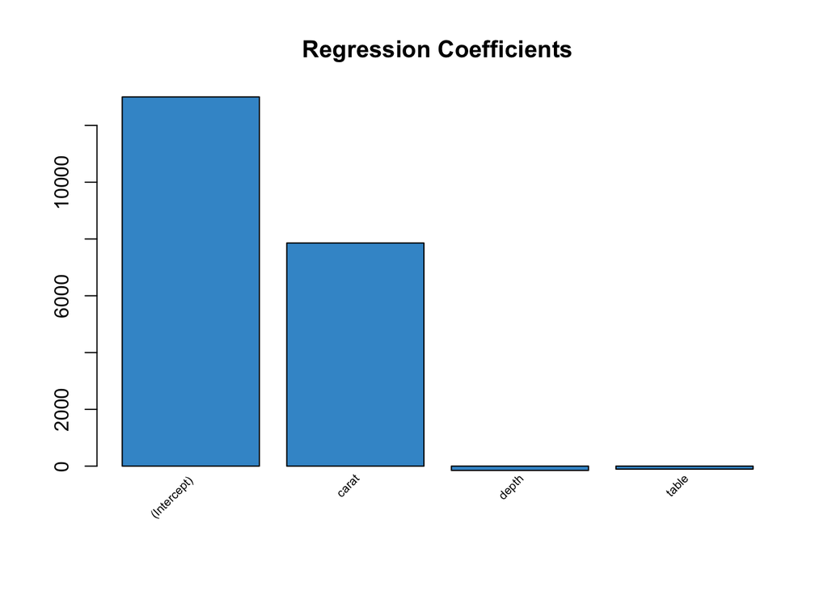

```r
plot_coeffs(fit)
```

The y-intercept is 13003. The slope for `carat` is 7859. The slope for `depth` is -151. The slope for `table` is -104.The variable `carat`, `depth` and `table` are significant because the p-value is less than 0.05. The coefficient of determination is 0.854.

price = 7859 * carat - 151 * depth - 104 * table + 13003

When the diamond carat goes up by 1, we would expect the price to go up by 7859 when all other variables are held constant

When the diamond depth goes up by 1, we would expect the price to go down by 151 when all other variables are held constant

When the diamond table goes up by 1, we would expect the price to go down by 104 when all other variables are held constant

When the diamond carat, depth and table is 0 we would expect the price to be 13003. The intercept is of no interest, not very useful, and also not reliable since the predicted value of the intercept so far from the bulk of the data. The minimun for carat is 0.2, depth is 43, and table is 43.

### Question 6

Using backward-selection and p-value as the selection criterion, determine the best model. You do not need to show all steps in your answer, just the output for the final model. Also, write down the final regression equation and interpret it.

```r
m_full <- lm(price ~ carat + cut + color + clarity + depth + table + x + y + z, data = diamonds)
summary(m_full)
```

```
##
## Call:
## lm(formula = price ~ carat + cut + color + clarity + depth +
##     table + x + y + z, data = diamonds)
##
## Residuals:
##    Min     1Q Median     3Q    Max
## -21376   -592   -183    376  10694
##
## Coefficients:
##              Estimate Std. Error t value             Pr(>|t|)
## (Intercept)   2184.48     408.20    5.35          0.000000088 ***
## carat        11256.98      48.63  231.49 < 0.0000000000000002 ***
## cutGood        579.75      33.59   17.26 < 0.0000000000000002 ***
## cutIdeal       832.91      33.41   24.93 < 0.0000000000000002 ***
## cutPremium     762.14      32.23   23.65 < 0.0000000000000002 ***
## cutVery Good   726.78      32.24   22.54 < 0.0000000000000002 ***
## colorE        -209.12      17.89  -11.69 < 0.0000000000000002 ***
## colorF        -272.85      18.09  -15.08 < 0.0000000000000002 ***
## colorG        -482.04      17.72  -27.21 < 0.0000000000000002 ***
## colorH        -980.27      18.84  -52.04 < 0.0000000000000002 ***
## colorI       -1466.24      21.16  -69.29 < 0.0000000000000002 ***
## colorJ       -2369.40      26.13  -90.67 < 0.0000000000000002 ***
## clarityIF     5345.10      51.02  104.76 < 0.0000000000000002 ***
## claritySI1    3665.47      43.63   84.00 < 0.0000000000000002 ***
## claritySI2    2702.59      43.82   61.68 < 0.0000000000000002 ***
## clarityVS1    4578.40      44.55  102.78 < 0.0000000000000002 ***
## clarityVS2    4267.22      43.85   97.31 < 0.0000000000000002 ***
## clarityVVS1   5007.76      47.16  106.19 < 0.0000000000000002 ***
## clarityVVS2   4950.81      45.85  107.97 < 0.0000000000000002 ***
## depth          -63.81       4.53  -14.07 < 0.0000000000000002 ***
## table          -26.47       2.91   -9.09 < 0.0000000000000002 ***
## x            -1008.26      32.90  -30.65 < 0.0000000000000002 ***
## y                9.61      19.33    0.50                 0.62
## z              -50.12      33.49   -1.50                 0.13
## ---
## Signif. codes:  0 '***' 0.001 '**' 0.01 '*' 0.05 '.' 0.1 ' ' 1
##
## Residual standard error: 1130 on 53916 degrees of freedom
## Multiple R-squared:  0.92,   Adjusted R-squared:  0.92
## F-statistic: 2.69e+04 on 23 and 53916 DF,  p-value: <0.0000000000000002
```

```r
# remove y because p-value is the highest
m_1 <- lm(price ~ carat + cut + color + clarity + depth + table + x + z, data = diamonds)
summary(m_1)
```

```
##
## Call:
## lm(formula = price ~ carat + cut + color + clarity + depth +
##     table + x + z, data = diamonds)
##
## Residuals:
##    Min     1Q Median     3Q    Max
## -21379   -592   -184    376  10694
##
## Coefficients:
##              Estimate Std. Error t value             Pr(>|t|)
## (Intercept)   2198.89     407.16    5.40          0.000000067 ***
## carat        11257.75      48.60  231.63 < 0.0000000000000002 ***
## cutGood        580.33      33.57   17.29 < 0.0000000000000002 ***
## cutIdeal       833.35      33.40   24.95 < 0.0000000000000002 ***
## cutPremium     762.29      32.23   23.65 < 0.0000000000000002 ***
## cutVery Good   727.43      32.21   22.58 < 0.0000000000000002 ***
## colorE        -209.10      17.89  -11.69 < 0.0000000000000002 ***
## colorF        -272.84      18.09  -15.08 < 0.0000000000000002 ***
## colorG        -482.04      17.72  -27.21 < 0.0000000000000002 ***
## colorH        -980.25      18.84  -52.04 < 0.0000000000000002 ***
## colorI       -1466.26      21.16  -69.29 < 0.0000000000000002 ***
## colorJ       -2369.41      26.13  -90.68 < 0.0000000000000002 ***
## clarityIF     5345.42      51.02  104.77 < 0.0000000000000002 ***
## claritySI1    3665.74      43.63   84.02 < 0.0000000000000002 ***
## claritySI2    2702.85      43.81   61.69 < 0.0000000000000002 ***
## clarityVS1    4578.70      44.54  102.80 < 0.0000000000000002 ***
## clarityVS2    4267.48      43.85   97.32 < 0.0000000000000002 ***
## clarityVVS1   5008.03      47.16  106.20 < 0.0000000000000002 ***
## clarityVVS2   4951.10      45.85  107.98 < 0.0000000000000002 ***
## depth          -64.00       4.52  -14.17 < 0.0000000000000002 ***
## table          -26.50       2.91   -9.10 < 0.0000000000000002 ***
## x            -1000.35      28.80  -34.74 < 0.0000000000000002 ***
## z              -47.93      33.19   -1.44                 0.15
## ---
## Signif. codes:  0 '***' 0.001 '**' 0.01 '*' 0.05 '.' 0.1 ' ' 1
##
## Residual standard error: 1130 on 53917 degrees of freedom
## Multiple R-squared:  0.92,   Adjusted R-squared:  0.92
## F-statistic: 2.81e+04 on 22 and 53917 DF,  p-value: <0.0000000000000002
```

```r
# remove z because p-value is the highest
m_2 <- lm(price ~ carat + cut + color + clarity + depth + table + x, data = diamonds)
summary(m_2)
```

```
##
## Call:
## lm(formula = price ~ carat + cut + color + clarity + depth +
##     table + x, data = diamonds)
##
## Residuals:
##    Min     1Q Median     3Q    Max
## -21385   -592   -184    376  10695
##
## Coefficients:
##              Estimate Std. Error t value             Pr(>|t|)
## (Intercept)   2366.09     390.35    6.06         0.0000000014 ***
## carat        11256.97      48.60  231.63 < 0.0000000000000002 ***
## cutGood        580.24      33.57   17.28 < 0.0000000000000002 ***
## cutIdeal       833.26      33.40   24.95 < 0.0000000000000002 ***
## cutPremium     762.76      32.22   23.67 < 0.0000000000000002 ***
## cutVery Good   726.82      32.21   22.56 < 0.0000000000000002 ***
## colorE        -209.24      17.89  -11.69 < 0.0000000000000002 ***
## colorF        -272.83      18.09  -15.08 < 0.0000000000000002 ***
## colorG        -481.94      17.72  -27.20 < 0.0000000000000002 ***
## colorH        -980.12      18.84  -52.04 < 0.0000000000000002 ***
## colorI       -1466.18      21.16  -69.28 < 0.0000000000000002 ***
## colorJ       -2369.50      26.13  -90.68 < 0.0000000000000002 ***
## clarityIF     5344.34      51.01  104.76 < 0.0000000000000002 ***
## claritySI1    3664.91      43.63   84.01 < 0.0000000000000002 ***
## claritySI2    2702.08      43.81   61.67 < 0.0000000000000002 ***
## clarityVS1    4577.59      44.54  102.79 < 0.0000000000000002 ***
## clarityVS2    4266.61      43.85   97.31 < 0.0000000000000002 ***
## clarityVVS1   5007.06      47.15  106.19 < 0.0000000000000002 ***
## clarityVVS2   4950.17      45.85  107.97 < 0.0000000000000002 ***
## depth          -66.77       4.09  -16.32 < 0.0000000000000002 ***
## table          -26.46       2.91   -9.09 < 0.0000000000000002 ***
## x            -1029.48      20.55  -50.10 < 0.0000000000000002 ***
## ---
## Signif. codes:  0 '***' 0.001 '**' 0.01 '*' 0.05 '.' 0.1 ' ' 1
##
## Residual standard error: 1130 on 53918 degrees of freedom
## Multiple R-squared:  0.92,   Adjusted R-squared:  0.92
## F-statistic: 2.94e+04 on 21 and 53918 DF,  p-value: <0.0000000000000002
```

```r
# check solution
backwards <- step(m_full, direction = "backward", trace=TRUE )
```

```
## Start:  AIC=758426
## price ~ carat + cut + color + clarity + depth + table + x + y +
##     z
##
##           Df   Sum of Sq          RSS    AIC
## - y        1      315487  68857162189 758425
## <none>                    68856846702 758426
## - z        1     2860869  68859707571 758427
## - table    1   105582383  68962429086 758507
## - depth    1   252862696  69109709398 758622
## - cut      4   863571446  69720418149 759091
## - x        1  1199618465  70056465167 759356
## - color    6 17082056578  85938903280 770368
## - clarity  7 35703337259 104560183961 780945
## - carat    1 68439854033 137296700735 795649
##
## Step:  AIC=758425
## price ~ carat + cut + color + clarity + depth + table + x + z
##
##           Df   Sum of Sq          RSS    AIC
## <none>                    68857162189 758425
## - z        1     2662170  68859824359 758425
## - table    1   105835668  68962997857 758506
## - depth    1   256370889  69113533078 758623
## - cut      4   864090840  69721253030 759089
## - x        1  1541308872  70398471061 759617
## - color    6 17082493632  85939655821 770366
## - clarity  7 35708207241 104565369430 780946
## - carat    1 68519556419 137376718608 795679
```

### Question 7

What are the conditions to validate the model? Apply appropriate plots to check these conditions. Are all conditions passed? Is the model valid? Why or why not?

#### Linearity

The relationship between the explanatory and the response variable should be linear.

#### Nearly normal residuals

Both the histogram and probability plot show that the residual are not nearly normal. The majority of the residuals fall on the line but some do not. There are two tails. The residual are not nearly normal because of outliers or concerns and influential points.

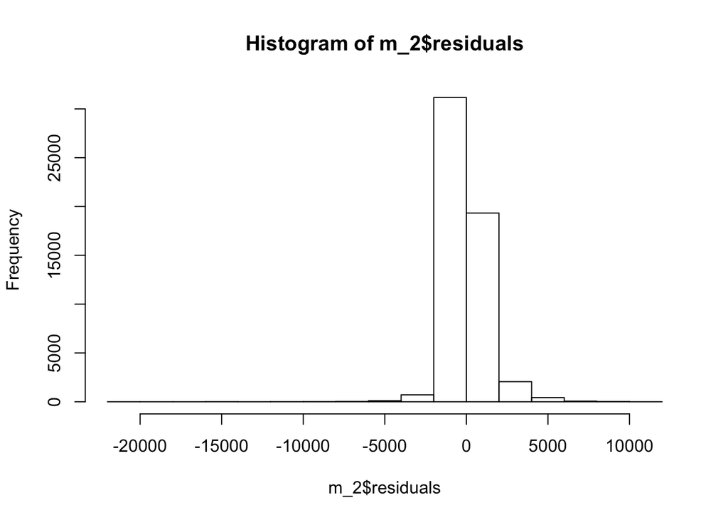

```r
# Nearly normal residuals
hist(m_2$residuals)
```

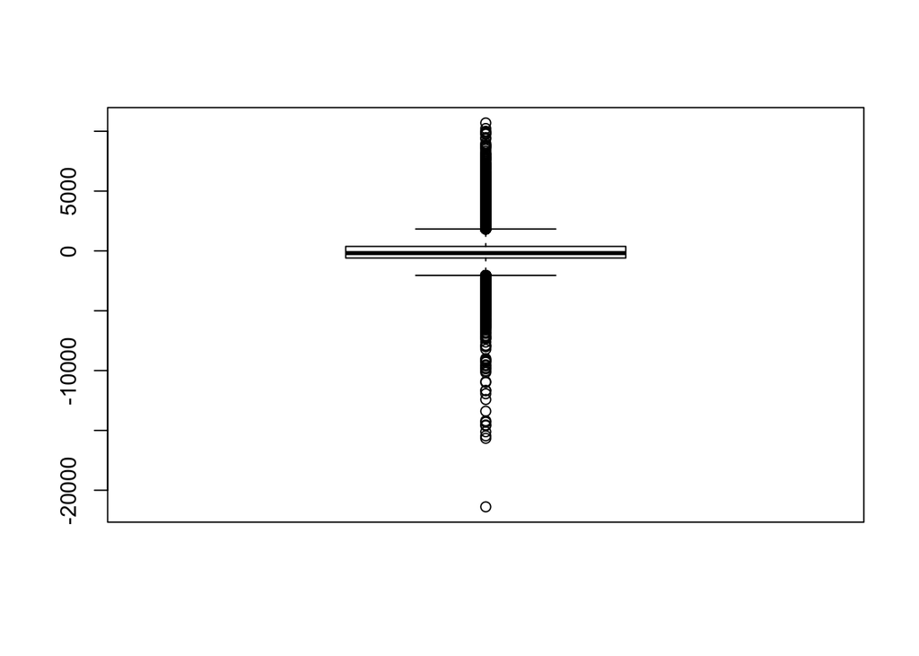

```r
boxplot(m_2$residuals)
```

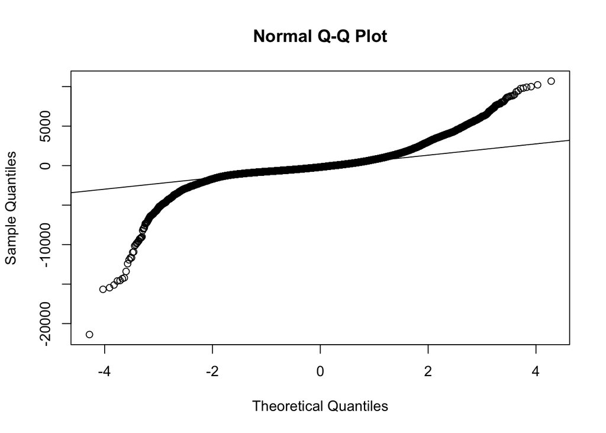

```r
# normal probability plot of the residuals
qqnorm(m_2$residuals)
qqline(m_2$residuals)  # adds diagonal line to the normal prob plot
```

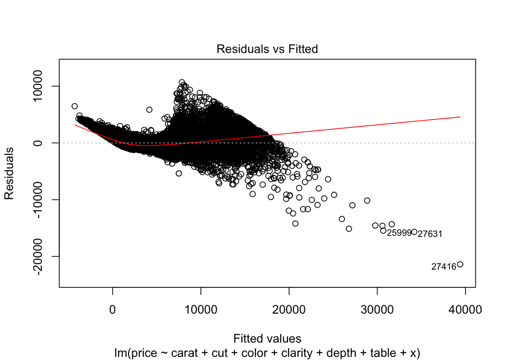

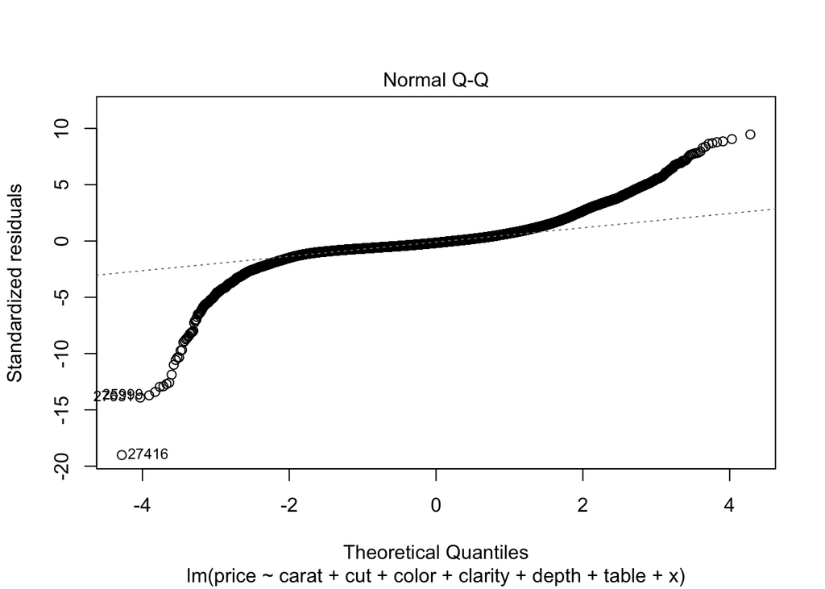

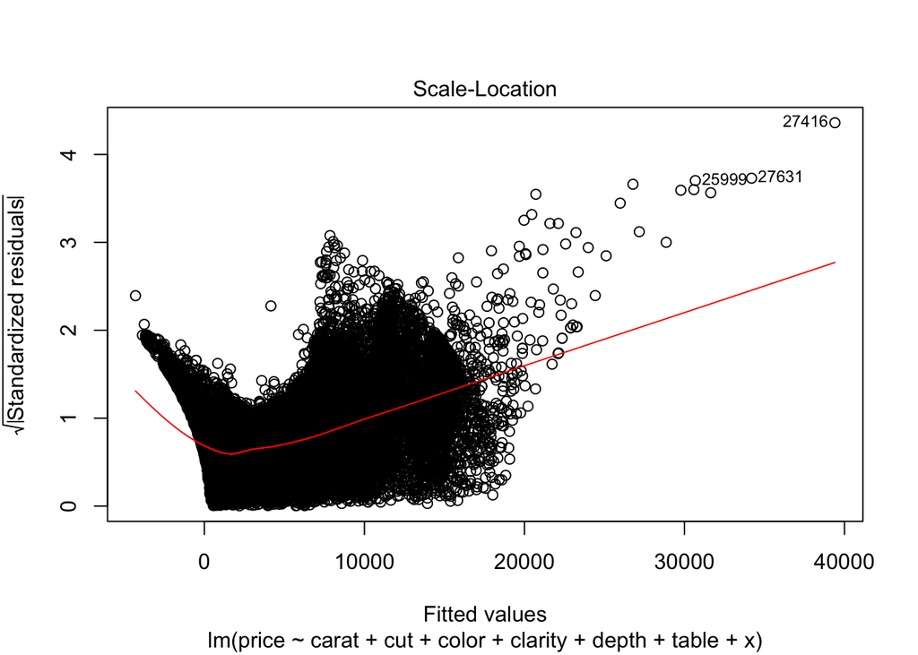

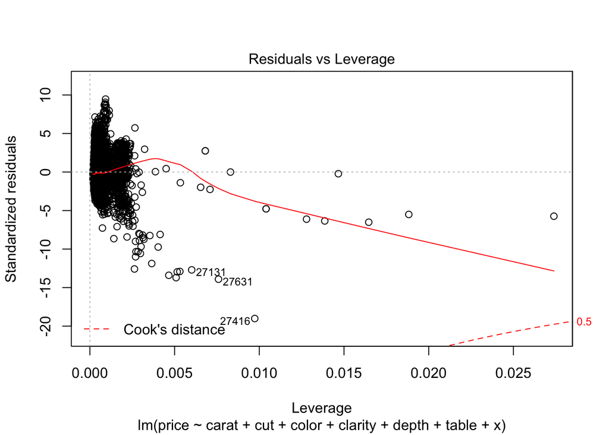

```r
plot(m_2)
```

#### Constant variability

The variability of points around the least squares line should be roughly constant but they are not.

#### No extreme outliers

The plot show a number of extreme outliers and influential points.

#### Independent observations

The observations are independent.

### Question 8

Based on your final model, what are the most important factors that influence the selling price of a diamond? Why?

There are many factors that can influence how much a consumer pays for a particular diamond. Most know the 4Cs – Cut, Color, Clarity and Carat.

When `carat` increases by 1, we would expect the price to go up by 11256.97 11256.97 when all other variables are held constant.

When `cut` is Fair, we would expect the price to no increase or decrease when all other variables are held constant.

When `cut` is Good, we would expect the price to go up by 580.24 when all other variables are held constant.

When `cut` is Ideal, we would expect the price to go up by 833.26 when all other variables are held constant.

When `cut` is Premium, we would expect the price to go up by 762.76 when all other variables are held constant.

When `cut` is Very Good, we would expect the price to go up by 726.82 when all other variables are held constant.

When `clarity` is IF, we would expect the price to go up by 5344.34 when all other variables are held constant.

When `clarity` is SI1, we would expect the price to go up by 3664.91 when all other variables are held constant.

When `clarity` is SI2, we would expect the price to go up by 2702.08 when all other variables are held constant.

When `clarity` is VS1, we would expect the price to go up by 4577.59 when all other variables are held constant.

When `clarity` is VS2, we would expect the price to go up by 4266.61 when all other variables are held constant.

When `clarity` is VVS1, we would expect the price to go up by 5007.06 when all other variables are held constant.

When `clarity` is VVS2, we would expect the price to go up by 4950.17 when all other variables are held constant.

When `color` is D, we would expect the price to no increase or decrease when all other variables are held constant.

When `color` is E, we would expect the price to go down by -209.24 when all other variables are held constant.

When `color` is F, we would expect the price to go down by -272.83 when all other variables are held constant.

When `color` is G, we would expect the price to go down by -481.94 when all other variables are held constant.

When `color` is H, we would expect the price to go down by -980.12 when all other variables are held constant.

When `color` is I, we would expect the price to go down by -1466.18 when all other variables are held constant.

When `color` is J, we would expect the price to go down by -2369.5 when all other variables are held constant.

When `x` increases by 1, we would expect the price to go down by -1029.48 when all other variables are held constant.

When `depth` increases by 1, we would expect the price to go down by -66.77 when all other variables are held constant.

When `table` increases by 1, we would expect the price to go down by -26.46 when all other variables are held constant.